# Coursework_3

Harry Wright

28 November 2016

#### 1. Random Forest

**In the lab, we applied random forests to the `Boston` data using `mtry=6` and using `ntree=25` and `ntree=500`. Create a plot displaying the test error resulting from random forests on this data set for a more comprehensive range of values for `mtry` and `ntree`. You can model your plot after Figure 8.10. Describe the results obtained.**

```r
library(randomForest)
```

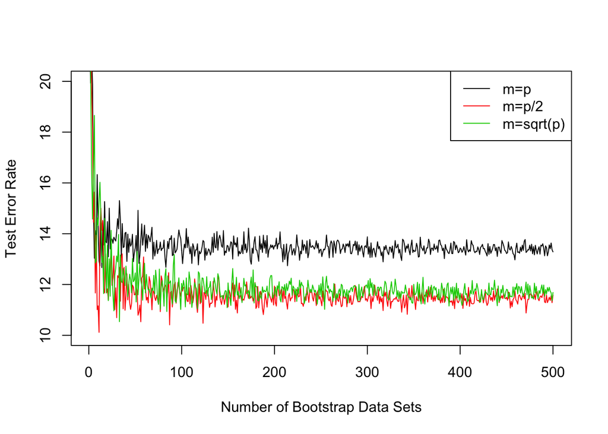

```r
library(MASS)
set.seed(1)
train=sample(nrow(Boston),nrow(Boston)/2)
boston.train<-Boston[train,]
boston.test<-Boston[-train,]
boston.testmse<-rep(0,500)
boston.mtry<-c(13,13/2,sqrt(13))

for(i in 1:3) {
  for(j in 1:500) {
    boston.model<-randomForest(medv~.,data=boston.train,mtry=boston.mtry[i],ntree=j,importance=TRUE)
    boston.yhat<-predict(boston.model,newdata=boston.test)
    boston.testmse[j]<-mean((boston.yhat-boston.test$medv)^2)
  }
  if(i==1) {
    plot(boston.testmse,xlab="Number of Bootstrap Data Sets",ylab="Test Error Rate",type="l",col=i,ylim=c(10,20))
  } else {
    lines(boston.testmse,col=i)
  }
}
legend("topright",c("m=p","m=p/2","m=sqrt(p)"),col=c(1,2,3),lty=1,lwd=1)
```

From the plot it can be observed that when m=p, the test mse is higher. The mse is much reduced in the red & green lines.

#### 2. Regression Tree

**In the lab, a classification tree was applied to the `Carseats` data set after converting `Sales` into a qualitative response variable. Now we will seek to predict `Sales` using regression trees and related approaches, treating the response as a quantitative variable.**

**a) Split the data set into training set and a test set.**

```r
library(ISLR)
library(tree)
set.seed(1)
train<-sample(1:nrow(Carseats),nrow(Carseats)/2)
Carseats.test<-Carseats[-train,]
Carseats.train<-Carseats[train,]
```

**b) Fit a regression tree to the training set. Plot the tree, and interpret the results. What test error rate do you obtain?**

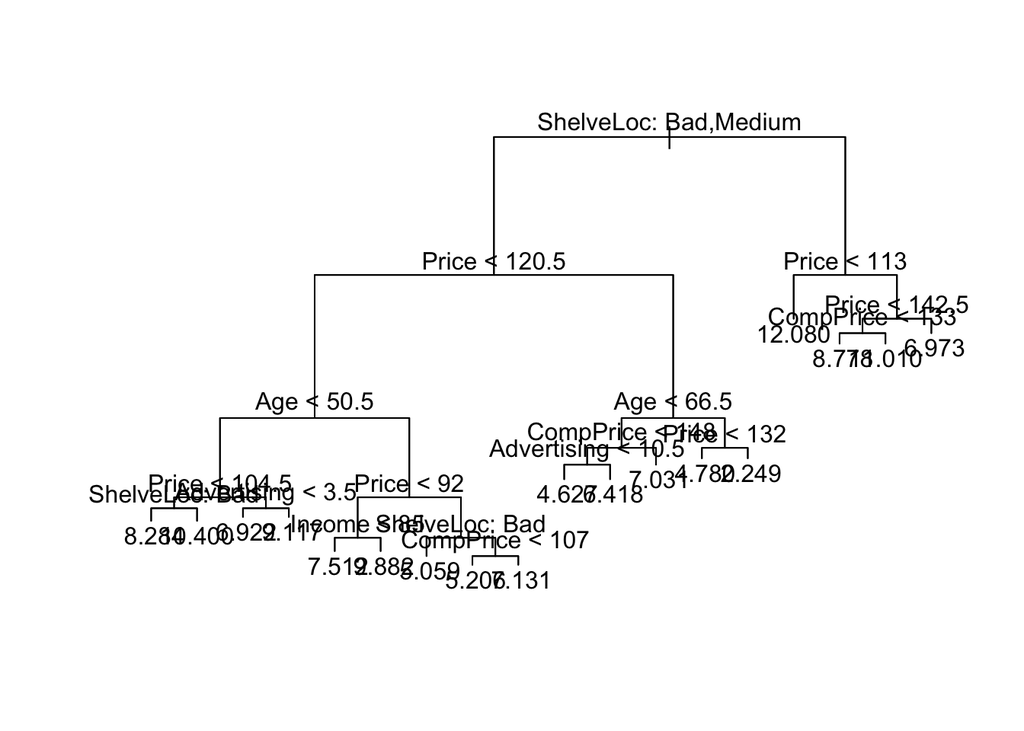

```r
carseats.tree.train<-tree(Sales~.,data=Carseats.train)
plot(carseats.tree.train)
text(carseats.tree.train,pretty=0)
```

```r
summary(carseats.tree.train)
```

```
##
## Regression tree:
## tree(formula = Sales ~ ., data = Carseats.train)
## Variables actually used in tree construction:
## [1] "ShelveLoc"   "Price"       "Age"         "Advertising" "Income"
## [6] "CompPrice"
## Number of terminal nodes:  18
## Residual mean deviance:  2.36 = 429.5 / 182
## Distribution of residuals:
##    Min. 1st Qu.  Median    Mean 3rd Qu.    Max.
## -4.2570 -1.0360  0.1024  0.0000  0.9301  3.9130
```

```r
yhat<-predict(carseats.tree.train,Carseats.test)
mean((yhat-Carseats.test$Sales)^2)
```

```
## [1] 4.148897
```

**c) Use cross-validation in order to determine the optimal level of tree complexity. Does pruning the tree improve the test error rate?**

```r
cv.carseats<-cv.tree(carseats.tree.train)
cv.carseats
```

```
## $size
##  [1] 18 17 16 15 14 12 11 10  9  8  7  6  5  4  3  1
##
## $dev
##  [1] 1094.537 1085.178 1089.409 1069.294 1069.294 1075.806 1044.469
##  [8] 1039.212 1039.212 1041.308 1043.459 1064.162 1119.046 1120.344
## [15] 1270.012 1560.273
##
## $k
##  [1]      -Inf  15.48181  15.53599  18.69038  18.74886  21.05038  23.79480
##  [8]  25.78579  26.01210  30.10435  32.74801  53.28569  72.33061  78.19599
## [15] 141.73781 251.22901
##
## $method
## [1] "deviance"
##
## attr(,"class")
## [1] "prune"         "tree.sequence"
```

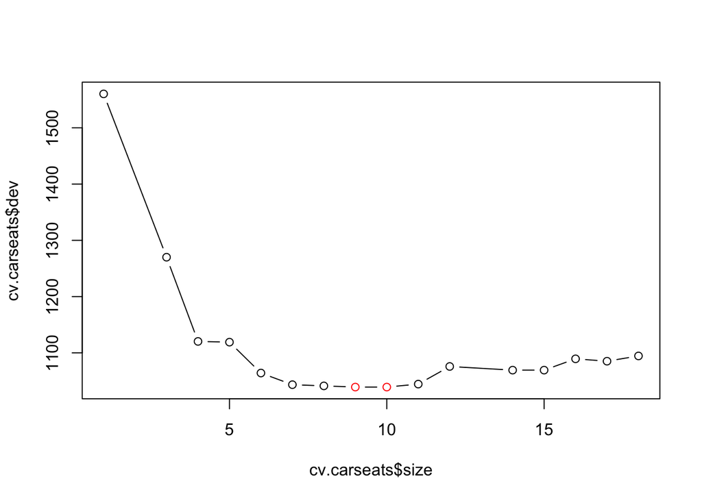

```r
plot(cv.carseats$size,cv.carseats$dev,type = 'b',col=ifelse(cv.carseats$size==9|cv.carseats$size==10,"red","black"))
```

The output from cv.carseats shows that the lowest MSE is where the tree size is 9 or 10 (please note that the $dev vector is indexed from the highest to lowest size, so the 8th and 9th elements in the vector actually refer to size==9 and size==10). These points are shown in red on the plot. We must now prune the tree and compare the test MSE.

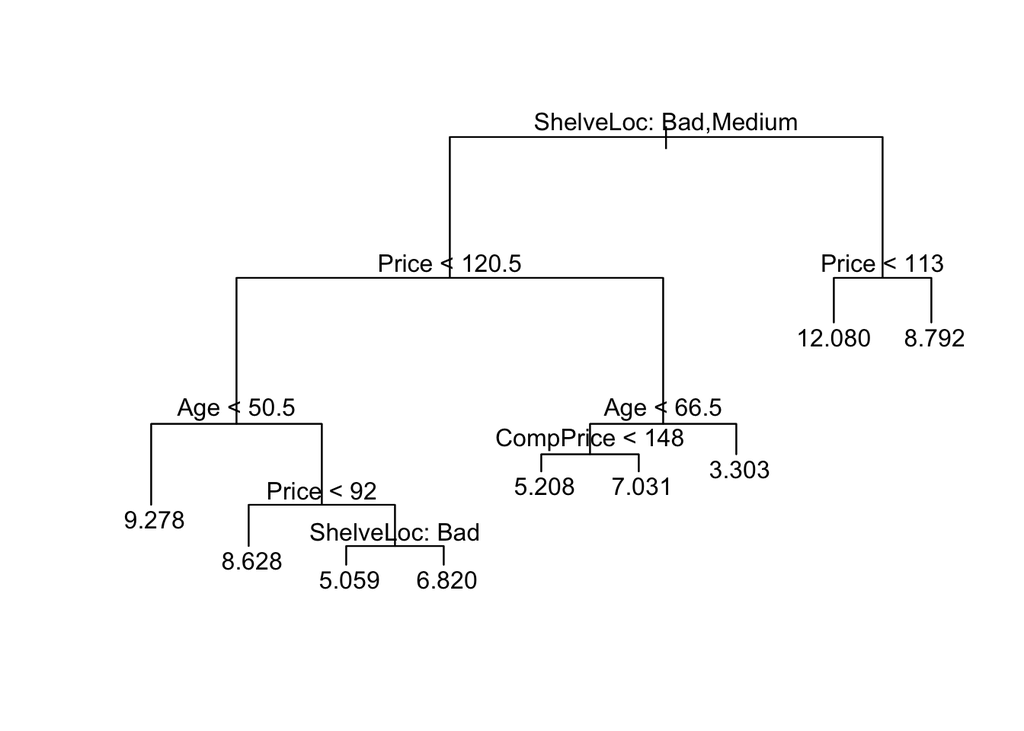

```r
prune.carseats<-prune.tree(carseats.tree.train,best=9)
plot(prune.carseats)
text(prune.carseats,pretty=0)
```

```r
yhat.pruned<-predict(prune.carseats,Carseats.test)
mean((yhat.pruned-Carseats.test$Sales)^2)
```

```
## [1] 4.993124
```

As size 9 or 10 showed an equal MSE, I have chosen to use size=9. After pruning to optimal size, `prune.carseats` exhibits a higher Test MSE of value 4.99.

**d) Use the bagging approach in order to determine the optimal level of tree complexity. What test error rate do you obtain? Use the `importance()` function to determine which variables are most important.**

```r
Carseats.bagging<-randomForest(Sales~.,data=Carseats.train,mtry=10,importance=TRUE)
Carseats.yhat<-predict(Carseats.bagging,newdata=Carseats.test)
mean((Carseats.yhat-Carseats.test$Sales)^2)
```

```
## [1] 2.604369
```

```r
importance(Carseats.bagging)
```

```
##                %IncMSE IncNodePurity
## CompPrice   14.4124562    133.731797
## Income       6.5147532     74.346961
## Advertising 15.7607104    117.822651
## Population   0.6031237     60.227867
## Price       57.8206926    514.802084
## ShelveLoc   43.0486065    319.117972
## Age         19.8789659    192.880596
## Education    2.9319161     39.490093
## Urban       -3.1300102      8.695529
## US           7.6298722     15.723975
```

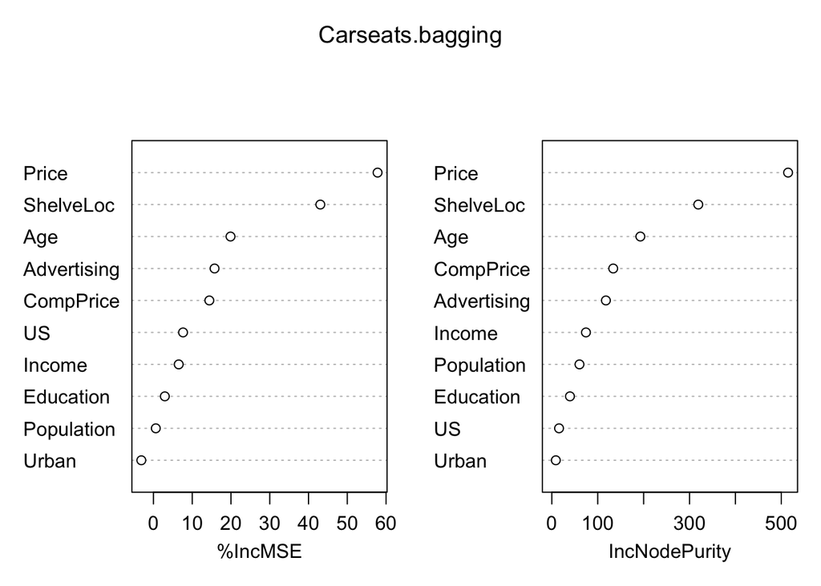

```r
varImpPlot(Carseats.bagging)
```

From above we can see that the test error rate when using bagging is 2.604369. From the importance function and corresponding variable importance plot, we can see that `Price` is by far the most important variable, followed by `ShelveLoc` then `Age` etc.

**e) Use random forests to analyse this data. What test error rate do you obtain? Use the importance() function to determine which variables are most important. Describe the effect of m, the number of variables considered at each split, on the error rate obtained.**

```r
Carseats.rf<-randomForest(Sales~.,data=Carseats.train,mtry=10/3,importance=TRUE)
Carseats.yhat<-predict(Carseats.rf,newdata=Carseats.test)
mean((Carseats.yhat-Carseats.test$Sales)^2)
```

```
## [1] 3.296078
```

```r
importance(Carseats.bagging)
```

```
##                %IncMSE IncNodePurity
## CompPrice   14.4124562    133.731797
## Income       6.5147532     74.346961
## Advertising 15.7607104    117.822651
## Population   0.6031237     60.227867
## Price       57.8206926    514.802084
## ShelveLoc   43.0486065    319.117972
## Age         19.8789659    192.880596
## Education    2.9319161     39.490093
## Urban       -3.1300102      8.695529
## US           7.6298722     15.723975
```

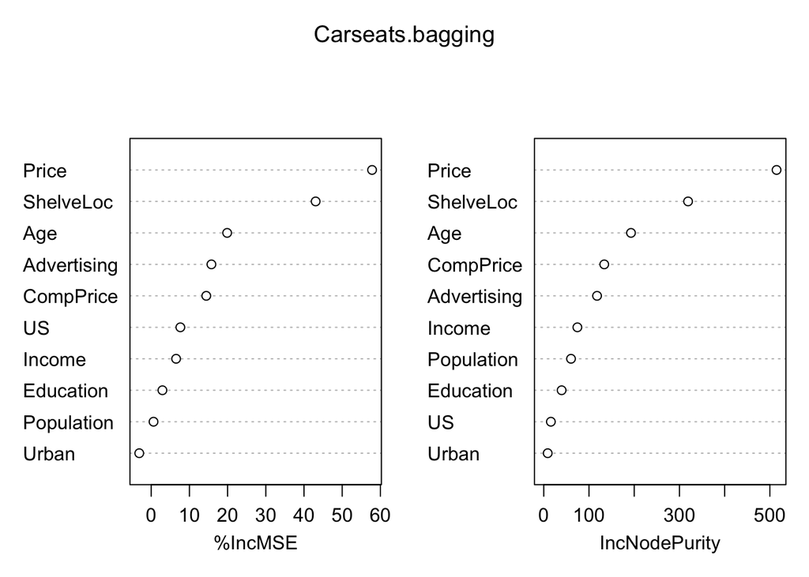

```r
varImpPlot(Carseats.bagging)
```

From the `importance` function and variable importance plot we can see that `Price` and `ShelveLoc` are by far the most important variables. Changing m in this case has increased the MSE to 3.296078.

#### 3. Classification Tree

**This problem involves the OJ data set which is part of the ISLR package.**

**a) Create a training set containing a random sample of 800 observations, and a test set containing the remaining observations.**

```r
set.seed(1)
train<-sample(nrow(OJ),800)
OJ.test<-OJ[-train,]
OJ.train<-OJ[train,]
```

**b) Fit a tree to the training data, with `Purchase` as the response and the other variables as predictors. Use the `summary()` function to produce summary statistics about the tree, and describe the results obtained. What is the training error rate? How many terminal nodes does the tree have?**

```r
OJ.train.tree<-tree(Purchase~.,data=OJ.train)
summary(OJ.train.tree)
```

```
##
## Classification tree:
## tree(formula = Purchase ~ ., data = OJ.train)
## Variables actually used in tree construction:
## [1] "LoyalCH"       "PriceDiff"     "SpecialCH"     "ListPriceDiff"
## Number of terminal nodes:  8
## Residual mean deviance:  0.7305 = 578.6 / 792
## Misclassification error rate: 0.165 = 132 / 800
```

From the results of `summary()` we can see that only four independent variables are used. The number of terminal nodes is 8. We can also see from the summary that the training error rate is 16.5%.

**c) Type in the name of the tree object in order to get a detailed text output. Pick one of the terminal nodes, and interpret the information displayed.**

```r
OJ.train.tree
```

```
## node), split, n, deviance, yval, (yprob)
##       * denotes terminal node
##
##  1) root 800 1064.00 CH ( 0.61750 0.38250 )
##    2) LoyalCH < 0.508643 350  409.30 MM ( 0.27143 0.72857 )
##      4) LoyalCH < 0.264232 166  122.10 MM ( 0.12048 0.87952 )
##        8) LoyalCH < 0.0356415 57   10.07 MM ( 0.01754 0.98246 ) *
##        9) LoyalCH > 0.0356415 109  100.90 MM ( 0.17431 0.82569 ) *
##      5) LoyalCH > 0.264232 184  248.80 MM ( 0.40761 0.59239 )
##       10) PriceDiff < 0.195 83   91.66 MM ( 0.24096 0.75904 )
##         20) SpecialCH < 0.5 70   60.89 MM ( 0.15714 0.84286 ) *
##         21) SpecialCH > 0.5 13   16.05 CH ( 0.69231 0.30769 ) *
##       11) PriceDiff > 0.195 101  139.20 CH ( 0.54455 0.45545 ) *
##    3) LoyalCH > 0.508643 450  318.10 CH ( 0.88667 0.11333 )
##      6) LoyalCH < 0.764572 172  188.90 CH ( 0.76163 0.23837 )
##       12) ListPriceDiff < 0.235 70   95.61 CH ( 0.57143 0.42857 ) *
##       13) ListPriceDiff > 0.235 102   69.76 CH ( 0.89216 0.10784 ) *
##      7) LoyalCH > 0.764572 278   86.14 CH ( 0.96403 0.03597 ) *
```

If we choose the terminal node at the bottom labelled 7, we can see that it is chosen if LoyalCH is > 0.764572. There are 278 observations in this branch and the deviation is 86.14. The prediction for this branch is CH. 96.4% of the observations in this branch are CH and 3.6% are MM.

**d) Create a plot of the tree and interpret the results.**

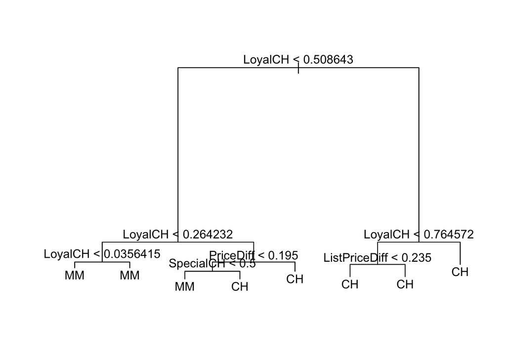

```r
plot(OJ.train.tree)
text(OJ.train.tree,pretty=0)
```

From the plot we can see that the most important factor for which juice brand will be chosen is LoyalCH. Customers who are loyal to the CH brand are more likely to choose CH.

**e) Predict the response on the test data, and produce a confusion matrix comparing the test labels to the predicted test labels. What is the test error rate?**

```r
OJ.test.pred<-predict(OJ.train.tree,OJ.test,type="class")
table(OJ.test.pred,OJ.test$Purchase)
```

```
##
## OJ.test.pred  CH  MM
##           CH 147  49
##           MM  12  62
```

```r
(12+49)/270
```

```
## [1] 0.2259259
```

The Test Error Rate is 22.6%.

**f) Apply the `cv.tree()` function to the training set in order to determine the optimal tree size.**

```r
OJ.cv.train.tree<-cv.tree(OJ.train.tree,FUN = prune.misclass)
OJ.cv.train.tree
```

```
## $size
## [1] 8 5 2 1
##
## $dev
## [1] 156 156 156 306
##
## $k
## [1]       -Inf   0.000000   4.666667 160.000000
##
## $method
## [1] "misclass"
##
## attr(,"class")
## [1] "prune"         "tree.sequence"
```

**g) Product a plot with tree size on the x-axis and cross-validated classification error rate on the y-axis.**

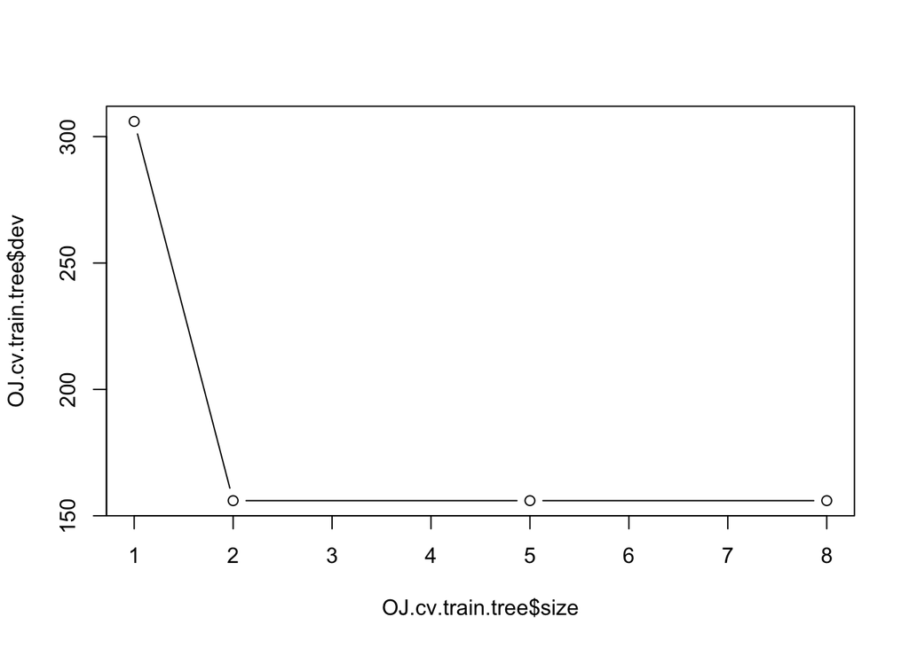

```r
plot(OJ.cv.train.tree$size,OJ.cv.train.tree$dev,type = 'b')
```

**h) Which tree size corresponds to the lowest cross-validated classification error rate?**

As can be seen from the results, tree sizes 2, 5 and 8 the lowest error rate (they are all equal).

**i) Produce a pruned tree corresponding to the optimal size obtained using cross-validation. If cross-validation does not lead to selection of a pruned tree, then create a pruned tree with five terminal nodes.**

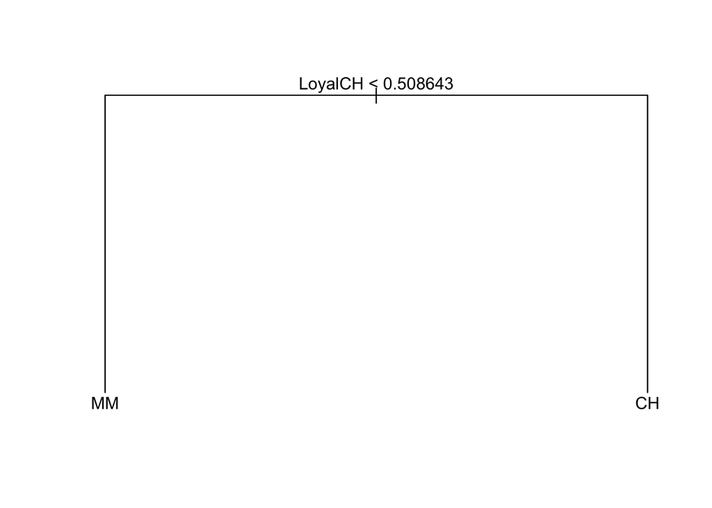

```r
OJ.train.tree.pruned<-prune.misclass(OJ.train.tree,best=2)
plot(OJ.train.tree.pruned)
text(OJ.train.tree.pruned,pretty=0)
```

**j) Compare the training error rates between the pruned and unpruned trees. Which is higher?**

```r
summary(OJ.train.tree)
```

```
##
## Classification tree:
## tree(formula = Purchase ~ ., data = OJ.train)
## Variables actually used in tree construction:
## [1] "LoyalCH"       "PriceDiff"     "SpecialCH"     "ListPriceDiff"
## Number of terminal nodes:  8
## Residual mean deviance:  0.7305 = 578.6 / 792
## Misclassification error rate: 0.165 = 132 / 800
```

```r
summary(OJ.train.tree.pruned)
```

```
##
## Classification tree:
## snip.tree(tree = OJ.train.tree, nodes = c(3L, 2L))
## Variables actually used in tree construction:
## [1] "LoyalCH"
## Number of terminal nodes:  2
## Residual mean deviance:  0.9115 = 727.4 / 798
## Misclassification error rate: 0.1825 = 146 / 800
```

The training error rate for the pruned tree is a little higher at 18.25%.

**k) Compare the test error rates between the pruned and unpruned trees. Which is higher?**

```r
OJ.test.pruned.pred<-predict(OJ.train.tree.pruned,OJ.test,type="class")
table(OJ.test.pruned.pred,OJ.test$Purchase)
```

```
##
## OJ.test.pruned.pred  CH  MM
##                  CH 119  30
##                  MM  40  81
```

```r
(40+30)/270
```

```
## [1] 0.2592593
```

Recall that the test error rate for the unpruned tree `OJ.train.tree` is 22.6% (from question 3e). The above shows the test error rate for the pruned tree is 26%, which is higher than for the unpruned tree.